# Confidence Intervals Minilab

2020-04-01

```r
library(infer)
library(janitor)
library(tidyverse)
```

The data set used for this exercise, `ames.csv`, explores the prices and condition of houses sold in in Ames, Iowa over a number of years.

```r
ames <- read_csv("data/ames.csv") %>%
  clean_names()
```

```r
glimpse(ames)
```

```
## Observations: 2,930
## Variables: 82
## $ order           <dbl> 1, 2, 3, 4, 5, 6, 7, 8, 9, 10, 11, 12, 13, 14, 15, ...
## $ pid             <dbl> 526301100, 526350040, 526351010, 526353030, 5271050...
## $ ms_sub_class    <dbl> 20, 20, 20, 20, 60, 60, 120, 120, 120, 60, 60, 20, ...
## $ ms_zoning       <chr> "RL", "RH", "RL", "RL", "RL", "RL", "RL", "RL", "RL...
## $ lot_frontage    <dbl> 141, 80, 81, 93, 74, 78, 41, 43, 39, 60, 75, NA, 63...
## $ lot_area        <dbl> 31770, 11622, 14267, 11160, 13830, 9978, 4920, 5005...
## $ street          <chr> "Pave", "Pave", "Pave", "Pave", "Pave", "Pave", "Pa...
## $ alley           <chr> NA, NA, NA, NA, NA, NA, NA, NA, NA, NA, NA, NA, NA,...
## $ lot_shape       <chr> "IR1", "Reg", "IR1", "Reg", "IR1", "IR1", "Reg", "I...
## $ land_contour    <chr> "Lvl", "Lvl", "Lvl", "Lvl", "Lvl", "Lvl", "Lvl", "H...
## $ utilities       <chr> "AllPub", "AllPub", "AllPub", "AllPub", "AllPub", "...
## $ lot_config      <chr> "Corner", "Inside", "Corner", "Corner", "Inside", "...
## $ land_slope      <chr> "Gtl", "Gtl", "Gtl", "Gtl", "Gtl", "Gtl", "Gtl", "G...
```

[output cut: 69 more lines]

# Question 1

*Plot a histogram of `sale_price`. Is the distribution normal?*

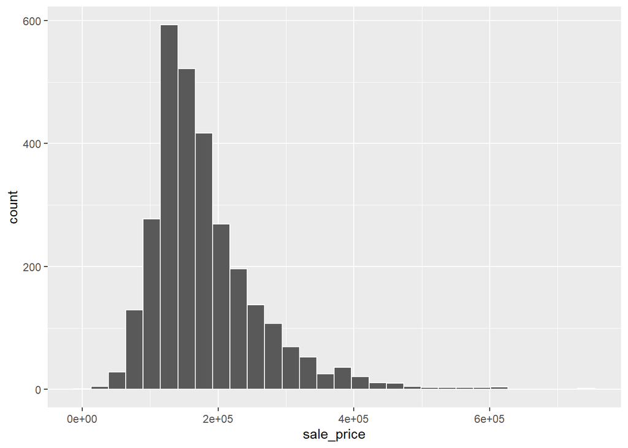

```r
ames %>%
  ggplot() +
  aes(
    x = sale_price
  ) +
  geom_histogram(
    bins = 30,
    col = "white"
  )
```

# Question 2

*Calculate the population parameter mean of `sale_price`. Store it in a variable, as we’ll need this value later when we check if each CI contains the parameter value or not.*

```r
ames_sale_mean <- mean(ames$sale_price)
```

# Question 3

Now we are going to:

- Take 1,000 random samples each of size 100 from `sale_price` in `ames`,
- Create a boostrap sampling distribution of `mean(sale_price)` from each 100-observation sample (using 1000 reps),
- Calculate the 95% CI (confidence interval) for each bootstrap distribution,
- Store the upper and lower bounds of the CI in a tibble called `results`,

By using the infer workflow to generate the bootstrap distributions and CIs.

```r
# Generate an empty tibble to populate
results <- tibble()

# Start of for loop
for (sample_number in 1:1000) {

  # Take a random sample of size 100 from `sale_price`
  sample <- ames %>%
    select(
      sale_price
    ) %>%
    rep_sample_n(
      size = 100,
      reps = 1
    ) %>%
    ungroup()

  # Create a bootstrap sampling distribution of `mean(sale_price)` from the above random sample
  bootstrap <- sample %>%
    specify(
      response = sale_price
    ) %>%
    generate(
      reps = 1000,
      type = "bootstrap"
    ) %>%
    calculate(
      stat = "mean"
    )

  # Calculate the 95% CI
  ci_95 <- bootstrap %>%
    get_ci(
      level = 0.95,
      type = "percentile"
    )

  # Store result in a vector
  result <- c(
    sample_number = sample_number,
    lower = ci_95[[1]],
    upper = ci_95[[2]]
  )

  # Bind result vector to results tibble
  results <- bind_rows(
    results,
    result
  )

}
```

# Question 4

*Pipe `results` to `mutate()` to add a new variable `popn_param_in_ci` which will be `TRUE` if the population parameter we calculated earlier is between lower and upper, and `FALSE` otherwise.*

```r
results_in_ci <- results %>%
  mutate(
    popn_param_in_ci =
      lower <= ames_sale_mean &
      upper >= ames_sale_mean
  )
```